# Survival analysis Raji model

Leander Meuris

2025-07-09

# Description of experiments

Purpose of the experiment is to look at the effect of MGAT5 engineering in CART-cells in a mouse tumor model. The model uses Raji cells, which create blood tumors of the Burkitt’s lymphoma type. These cells are CD70 positive.

The experiment has the following timeline:

- day 0: injection of 500 000 Raji cells IV
- day 6: IVIS baseline measurement
- day 7: treatment (CAR T injection iv in different doses and controls)

Experiment 51:

- PBS: no cells given
- NTC: 4 million cells donor T-cells, no CAR T cells
- CD70 CART WT 4 million cells
- CD70 CART MGAT5 4 million cells
- CD70 CART WT 2 million cells
- CD70 CART MGAT5 2 million cells

Experiment 62 and 68:

- NTC: 4 million cells donor T-cells, no CAR T cells
- CD70 CART WT 4 million cells
- CD70 CART MGAT5 4 million cells

Experiment 74: used 6 mice per group, and no CD19 CART cells:

- NTC: 4 million cells donor T-cells, no CAR T cells
- CD70 CART WT 4 million cells
- CD70 CART MGAT5 4 million cells

There was a rechallenge part to experiments 51 and 74, but not to 62 and 68. A rechallenge means that tumor cells were administered again after a set period. We also note the end-day of the experiments, as we need this for calculations of the survival times.

```r
day_rechallenge_E51 <- 133
day_rechallenge_E62 <- NA
day_rechallenge_E68 <- NA
day_rechallenge_E74 <- 139

day_end_E51 <- 216
day_end_E62 <- 83
day_end_E68 <- 88
day_end_E74 <- 202
```

The question we want to answer are:

Is the MGAT5 effect tumor model independent? I.e. do we see an MGAT5 effect in these experiments like we saw in the SKOV3 tumor model?

In this particular script, we will focus on the survival analysis.

# Data

First, we load all the data

```r
sheets <- excel_sheets(here('data/data_cleaned.xlsx'))
datalist <- map(sheets, read_xlsx, path = here('data/data_cleaned.xlsx'))
names(datalist) <- sheets
```

## Metadata & Survival data

Get the metadata

```r
metadata <- datalist$Metadata
Survival <- datalist$Survival
Survival <- left_join(Survival, metadata)
```

In the survival data;

- Event1: event during primary challenge
  - 0 = mouse did not experience an event
  - 1 = mouse died of tumor
  - 2 = mouse died of other cause (unknown, GVHD, …)
- Event2: event during rechallenge, only for mice that survived primary challenge.
  - 0 = mouse did not experience an event
  - 1 = mouse died of tumor
  - 2 = mouse died of other cause (unknown, GVHD, …)

## Weight data

Get the bodyweight data for each experiment, Put in long format, Combine data from 4 experiments into one large dataframe, Remove lines with missing weight data Select relevant columns and sort

```r
Weight <- datalist[str_detect(names(datalist), 'Weight')] %>% # select only weight data
  map(~ pivot_longer(.x,
                     cols = -Day,
                     names_to = 'Mouse',
                     values_to= 'Weight')) %>%
  bind_rows(.id = 'Experiment') %>%
  mutate(Experiment = str_remove(Experiment, 'Weight'),
         Mouse = as.numeric(Mouse)) %>%
  filter(!is.na(Weight)) %>%
  select(Experiment, Mouse, Day, Weight) %>%
  arrange(Experiment, Mouse, Day)

Weight <- left_join(Weight, Survival) %>%
  mutate(GVHD = ifelse(is.na(GVHD), 'No or unknown', GVHD),
         Event1 = factor(Event1,
                        labels = c('Survived',
                                   'Died of tumor',
                                   'Died of other cause')),
         Event2 = factor(Event2,
                        labels = c('Survived',
                                   'Died of tumor',
                                   'Died of other cause')))
```

Clean up

```r
rm(metadata, datalist, sheets)
```

# Data cleaning

Parse variables to correct type Remove some data that are superfluous or problematic:

EXP51: - Mouse 21 in exp 51 was a sentinel mouse

EXP62: - Mouse 26 and 27 in exp 62 were spare, were not used - Mouse 18, 23, 24, 25, 28 in exp 62 died from heat of the lamps so cannot be used in analysis

EXP68: - Mice 1, 22 were not in the experiment and 38-43 were backup in exp 68.

EXP74: - Mouse 22: euthanized due to unsure Raji injection - Mouse 30: euthanized by accident - Mouse 29: excluded due to unsure Raji injection - Mouse 46 and 47: controls for Raji effectiveness at secondary injection

```r
Weight <- Weight %>%
  filter(!(Mouse %in% c(18,23,24,25,26,27,28) & Experiment == 'E62')) %>%
  filter(!(Mouse == 21 & Experiment == 'E51')) %>%
  filter(!(Mouse %in% c(1,22,38,39,40,41,42,43) & Experiment == 'E68')) %>%
  filter(!(Mouse %in% c(22,29,30,46,47) & Experiment == 'E74')) %>%
  arrange(Experiment, Mouse, Day) %>%
  mutate(Experiment = factor(Experiment),
         ID = fct_inorder(paste0(Experiment, 'M', Mouse)),
         Treatment = factor(Treatment),
         Target = factor(Target, levels =c('Ctrl', 'CD70')),
         MGAT5 = factor(MGAT5, levels = c('Ctrl', 'MGAT5WT', 'MGAT5KO')),
         Dose = factor(Dose, levels = c('0','1','0.5','2','4'))) %>%
  select(Experiment, Mouse, ID, everything())

Survival <- Survival %>%
  filter(!(Mouse %in% c(18,23,24,25,26,27,28) & Experiment == 'E62')) %>%
  filter(!(Mouse == 21 & Experiment == 'E51')) %>%
  filter(!(Mouse %in% c(1,22,38,39,40,41,42,43) & Experiment == 'E68')) %>%
  filter(!(Mouse %in% c(22,29,30,46,47) & Experiment == 'E74')) %>%
  arrange(Experiment, Mouse) %>%
  mutate(Experiment = factor(Experiment),
         ID = fct_inorder(paste0(Experiment, 'M', Mouse)),
         Treatment = factor(Treatment),
         Target = factor(Target, levels =c('Ctrl', 'CD70')),
         MGAT5 = factor(MGAT5, levels = c('Ctrl', 'MGAT5WT', 'MGAT5KO')),
         Dose = factor(Dose, levels = c('0','0.5','1','2','4'))) %>%
  select(Experiment, Mouse, ID, everything())
```

Get follow up times for the survival analysis. These can be obtained from the Weight dataframe. We have follow up times for: - the primary challenge: the latest day there was an observation before the day of rechallenge, or the day of rechallenge itself. In the latter case, we have a censored observation. This is Time_FU_1. - the secondary challenge (rechallenge): the latest day there was an observation before the end of the experiment or the end of the experiment. In the latter case, we have a censored observation. This is Time_FU_2

```r
FUtimes_1 <- Weight %>%
  group_by(Experiment, ID) %>%
  filter(Day == max(Day)) %>%
  select(Experiment, ID, Day) %>%
  mutate(Time_FU_1 = case_when(
    Experiment == 'E51' ~ pmin(Day, day_rechallenge_E51),
    Experiment %in% c('E62', 'E68') ~ Day,
    Experiment == 'E74' ~ pmin(Day, day_rechallenge_E74)
  )) %>%
  select(-Day)

FUtimes_2 <- Weight %>%
  group_by(Experiment, ID) %>%
  filter(Day == max(Day)) %>%
  select(Experiment, ID, Day) %>%
  mutate(Time_FU_2 = case_when(
    Experiment == 'E51' ~ pmin(Day, day_end_E51),
    Experiment == 'E62' ~ NA,
    Experiment == 'E68' ~ NA,
    Experiment == 'E74' ~ pmin(Day, day_end_E74),
  )) %>%
  select(-Day)

Survival <- left_join(Survival, FUtimes_1)
Survival <- left_join(Survival, FUtimes_2)
rm(Weight, FUtimes_1, FUtimes_2)

Survival <- Survival %>%
  filter(!is.na(Target))
```

Write datasheets to xlsx files for later reference

```r
#Survival %>% writexl::write_xlsx(here('output/Survival.xlsx'))
```

Some data QC

```r
#Survival %>% map(~any(is.na(.)))
#Survival %>%
#  filter(Experiment %in% c('E51', 'E74')) %>%
#  filter(is.na(Event2))
```

# Survival tables and plots

## Primary tumor, all experiments combined

We check how many mice died of the tumor in each treatment setting. First, we filter out all mice for which the cause of death was unknown, GVHD, etc (i.e. not the tumor) during the first challenge.

```r
tableall <- knitr::kable(Survival %>%
  filter(is.na(CauseOfDeath1)) %>%
  group_by(Target, Dose, MGAT5, Treatment) %>%
  summarise(Total = n(),
            Cases = sum(Event1 == 1)) %>%
  mutate(`%` = signif(Cases/Total, 3)*100,
         Case_Tot_pct = paste0(`%`, '%', ' (', Cases, '/', Total, ')')) %>%
  select(-c(Cases, Total, `%`)) %>%
  arrange(Target, Dose, MGAT5, Treatment)
)

tableall %>% kableExtra::save_kable(file = here("output/TablePrimary_All.pdf"))
tableall %>% kableExtra::kable_styling()
```

| Target | Dose | MGAT5 | Treatment | Case_Tot_pct |
| --- | --- | --- | --- | --- |
| Ctrl | 0 | Ctrl | PBS | 100% (5/5) |
| Ctrl | 4 | Ctrl | NTC | 100% (21/21) |
| CD70 | 2 | MGAT5WT | CD70 nanoCAR-WT - 2 000 000 | 100% (5/5) |
| CD70 | 2 | MGAT5KO | CD70 nanoCAR-KO - 2 000 000 | 100% (5/5) |
| CD70 | 4 | MGAT5WT | CD70 nanoCAR-WT - 4 000 000 | 77.3% (17/22) |
| CD70 | 4 | MGAT5KO | CD70 nanoCAR-KO - 4 000 000 | 36.8% (7/19) |

We can also show this graphically

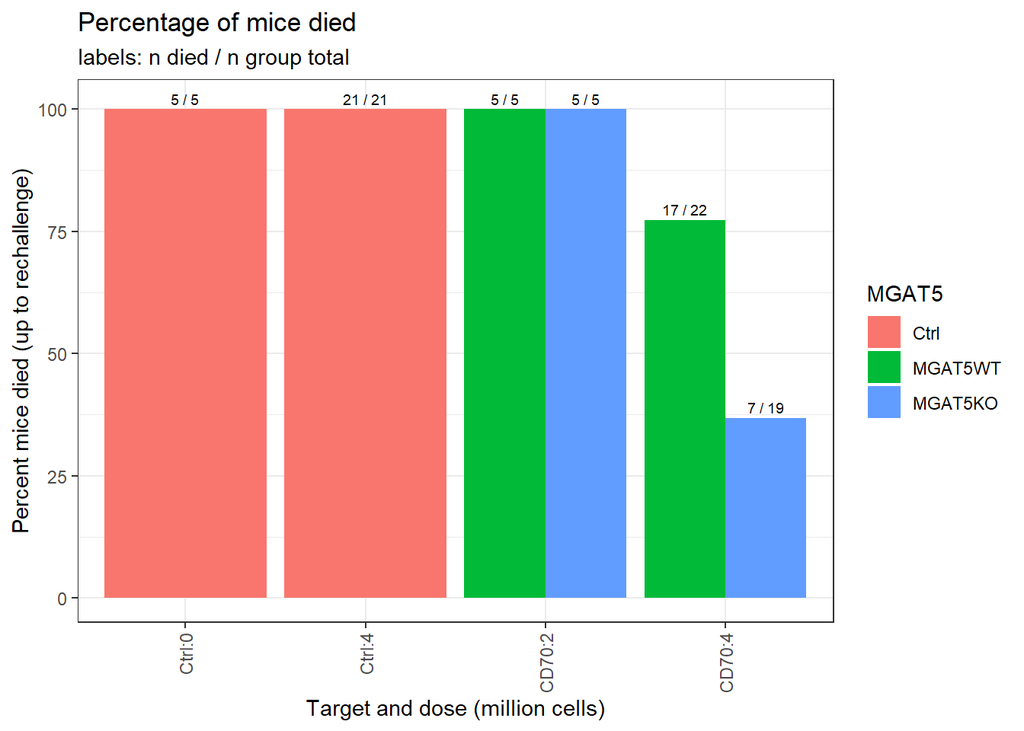

```r
Survival %>%
  filter(is.na(CauseOfDeath1)) %>%
  group_by(Target, Dose, MGAT5, Treatment) %>%
  summarise(Total = n(),
            Cases = sum(Event1 == 1)) %>%
  mutate(Pct = signif(Cases/Total, 3)*100) %>%
  ggplot(aes(x = Target:Dose, y = Pct, fill = MGAT5)) +
  geom_col(position = 'dodge') +
  geom_text(aes(label = paste0(Cases, ' / ', Total), y = Pct + 1), size = 2.5 ,
            vjust = 0, position = position_dodge(width = 0.9)) +
  ylab('Percent mice died (up to rechallenge)') +
  xlab('Target and dose (million cells)') +
  ggtitle('Percentage of mice died',
          subtitle = 'labels: n died / n group total') +
  theme_bw() +
  theme(axis.text.x = element_text(angle = 90, vjust = 0.5, hjust=1))
```

## Primary tumor, per experiment

```r
tableexp <- knitr::kable(Survival %>%
  filter(is.na(CauseOfDeath1)) %>%
  group_by(Experiment, Target, Dose, MGAT5, Treatment) %>%
  summarise(Total = n(),
            Cases = sum(Event1 == 1)) %>%
  mutate(`%` = signif(Cases/Total, 3)*100,
         Case_Tot_pct = paste0(`%`, '%', ' (', Cases, '/', Total, ')')) %>%
  select(-c(Cases, Total, `%`)) %>%
  arrange(Experiment, Target, Dose, MGAT5, Treatment)
)

tableexp %>% kableExtra::save_kable(file = here("output/TablePrimary_PerExp.pdf"))
tableexp %>% kableExtra::kable_styling()
```

| Experiment | Target | Dose | MGAT5 | Treatment | Case_Tot_pct |
| --- | --- | --- | --- | --- | --- |
| E51 | Ctrl | 0 | Ctrl | PBS | 100% (5/5) |
| E51 | Ctrl | 4 | Ctrl | NTC | 100% (5/5) |
| E51 | CD70 | 2 | MGAT5WT | CD70 nanoCAR-WT - 2 000 000 | 100% (5/5) |
| E51 | CD70 | 2 | MGAT5KO | CD70 nanoCAR-KO - 2 000 000 | 100% (5/5) |
| E51 | CD70 | 4 | MGAT5WT | CD70 nanoCAR-WT - 4 000 000 | 100% (5/5) |
| E51 | CD70 | 4 | MGAT5KO | CD70 nanoCAR-KO - 4 000 000 | 100% (5/5) |
| E62 | Ctrl | 4 | Ctrl | NTC | 100% (4/4) |
| E62 | CD70 | 4 | MGAT5WT | CD70 nanoCAR-WT - 4 000 000 | 25% (1/4) |
| E62 | CD70 | 4 | MGAT5KO | CD70 nanoCAR-KO - 4 000 000 | 0% (0/4) |
| E68 | Ctrl | 4 | Ctrl | NTC | 100% (5/5) |
| E68 | CD70 | 4 | MGAT5WT | CD70 nanoCAR-WT - 4 000 000 | 80% (4/5) |
| E68 | CD70 | 4 | MGAT5KO | CD70 nanoCAR-KO - 4 000 000 | 0% (0/4) |
| E74 | Ctrl | 4 | Ctrl | NTC | 100% (7/7) |
| E74 | CD70 | 4 | MGAT5WT | CD70 nanoCAR-WT - 4 000 000 | 87.5% (7/8) |
| E74 | CD70 | 4 | MGAT5KO | CD70 nanoCAR-KO - 4 000 000 | 33.3% (2/6) |

We can also show this graphically

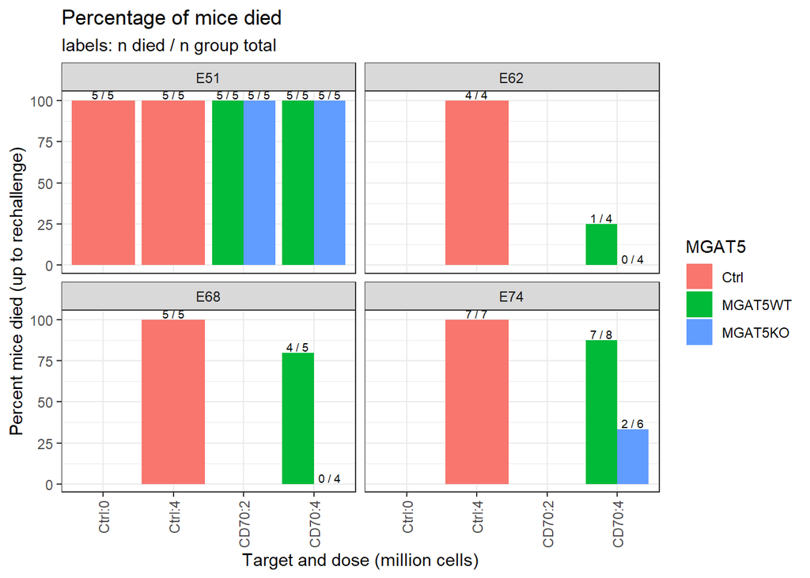

```r
Survival %>%
  filter(is.na(CauseOfDeath1)) %>%
  group_by(Experiment, Target, Dose, MGAT5, Treatment) %>%
  summarise(Total = n(),
            Cases = sum(Event1 == 1)) %>%
  mutate(Pct = signif(Cases/Total, 3)*100) %>%
  ggplot(aes(x = Target:Dose, y = Pct, fill = MGAT5)) +
  geom_col(position = 'dodge') +
  geom_text(aes(label = paste0(Cases, ' / ', Total), y = Pct + 1), size = 2.5 ,
            vjust = 0, position = position_dodge(width = 0.9)) +
  ylab('Percent mice died (up to rechallenge)') +
  xlab('Target and dose (million cells)') +
  ggtitle('Percentage of mice died',
          subtitle = 'labels: n died / n group total') +
  facet_wrap(~Experiment) +
  theme_bw() +
  theme(axis.text.x = element_text(angle = 90, vjust = 0.5, hjust=1))
```

## Rechallenge, all exp combined

We check how many mice died of the tumor in each treatment setting. First, we filter out all mice for which the cause of death was unknown, GVHD, etc (i.e. not the tumor)

```r
tableall2 <- knitr::kable(Survival %>%
  filter(is.na(CauseOfDeath2)) %>%
  filter(Experiment %in% c('E51', 'E74')) %>%
  filter(Event1 == 0) %>%
  group_by(Target, Dose, MGAT5, Treatment) %>%
  summarise(Total = n(),
            Cases = sum(Event2 == 1)) %>%
  mutate(`%` = signif(Cases/Total, 3)*100,
         Case_Tot_pct = paste0(`%`, '%', ' (', Cases, '/', Total, ')')) %>%
  select(-c(Cases, Total, `%`)) %>%
  arrange(Target, Dose, MGAT5, Treatment)
)

tableall2 %>% kableExtra::save_kable(file = here("output/TablePrimary_All.pdf"))
tableall2 %>% kableExtra::kable_styling()
```

| Target | Dose | MGAT5 | Treatment | Case_Tot_pct |
| --- | --- | --- | --- | --- |
| CD70 | 4 | MGAT5WT | CD70 nanoCAR-WT - 4 000 000 | 100% (1/1) |
| CD70 | 4 | MGAT5KO | CD70 nanoCAR-KO - 4 000 000 | 100% (4/4) |

We can also show this graphically

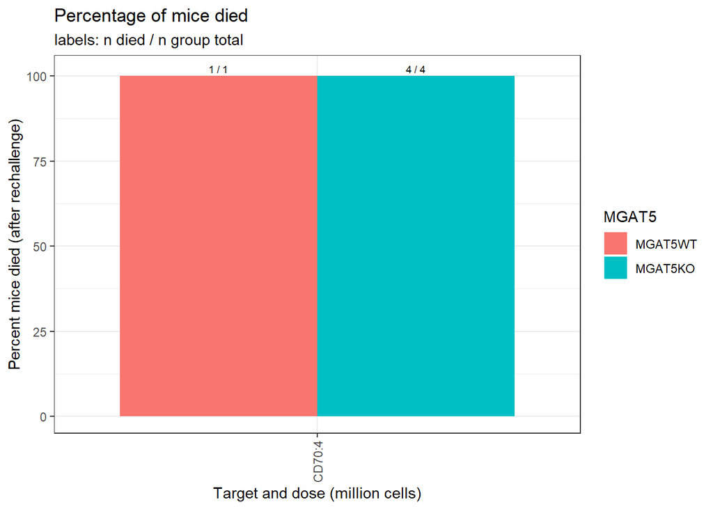

```r
Survival %>%
  filter(is.na(CauseOfDeath2)) %>%
  filter(Experiment %in% c('E51', 'E74')) %>%
  filter(Event1 == 0) %>%
  group_by(Target, Dose, MGAT5, Treatment) %>%
  summarise(Total = n(),
            Cases = sum(Event2 == 1)) %>%
  mutate(Pct = signif(Cases/Total, 3)*100) %>%
  ggplot(aes(x = Target:Dose, y = Pct, fill = MGAT5)) +
  geom_col(position = 'dodge') +
  geom_text(aes(label = paste0(Cases, ' / ', Total), y = Pct + 1), size = 2.5 ,
            vjust = 0, position = position_dodge(width = 0.9)) +
  ylab('Percent mice died (after rechallenge)') +
  xlab('Target and dose (million cells)') +
  ggtitle('Percentage of mice died',
          subtitle = 'labels: n died / n group total') +
  theme_bw() +
  theme(axis.text.x = element_text(angle = 90, vjust = 0.5, hjust=1))
```

# Survival analysis grouped

We will do the survival analysis per target. For each target, a certain dose was used as the ‘standard’ dose, and this is repeated in each experiment: - control (NTC): 4 million cells, all experiments - CD70: 4 million cells, all exps

We collect the data for each analysis in a separate dataframe. We also remove all mice that died from other causes (e.g. GVHD)

```r
Survival <- Survival %>%
  mutate(Event = ifelse(is.na(Event2), Event1, Event2),
         Time_FU = ifelse(is.na(Time_FU_2), Time_FU_1, Time_FU_2),
         cMGAT5 = as.character(MGAT5))

CD70 <- Survival %>%
  filter((Target == 'CD70' & Dose == '4') |
           (Target == 'Ctrl' & Dose == '4')) %>%
  filter(Event %in% c('0', '1'))

surv_CD70 <- Surv(CD70$Time_FU, CD70$Event)

simple_palette_CD70= c('grey',
                       rgb(255,0,0, maxColorValue = 255),
                       rgb(255,128,128, maxColorValue = 255))
stratify_palette_CD70 = c('grey',
                          rgb(255,128,128, maxColorValue = 255),
                          rgb(255,0,0, maxColorValue = 255))
```

## CD70

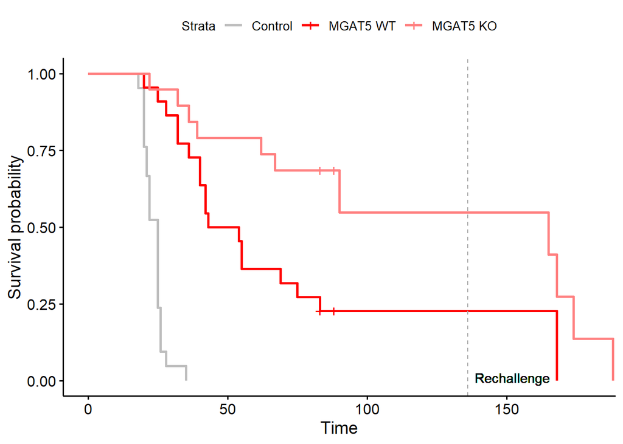

```r
sCD70 <- survfit2(surv_CD70 ~ MGAT5, data = CD70)
CD70_combi <- ggsurvplot(sCD70, data = CD70, palette = simple_palette_CD70,
                         legend.labs = c('Control', 'MGAT5 WT', 'MGAT5 KO'),
                         xlim = c(0,180))
CD70_perexp <- ggsurvplot_facet(sCD70, facet.by = 'Experiment', data = CD70,
                                palette = stratify_palette_CD70,
                                xlim = c(0,180))

CD70_combi$plot <- CD70_combi$plot +
  geom_vline(xintercept = 136, linetype = 'dashed', color = 'darkgrey') +
  geom_text(aes(x = 152, y = 0.01, label = 'Rechallenge'))

CD70_perexp <- CD70_perexp +
  geom_vline(xintercept = 136, linetype = 'dashed', color = 'darkgrey') +
  geom_text(aes(x = 162, y = 0.03, label = 'Rechallenge'), size = 3)

ggsave(here('output/CD70_combi.pdf'), CD70_combi$plot,
       device = 'pdf', width  = 8, height = 5)

ggsave(here('output/CD70_perexp.pdf'), CD70_perexp,
       device = 'pdf', width = 8, height = 5)

CD70_combi
```

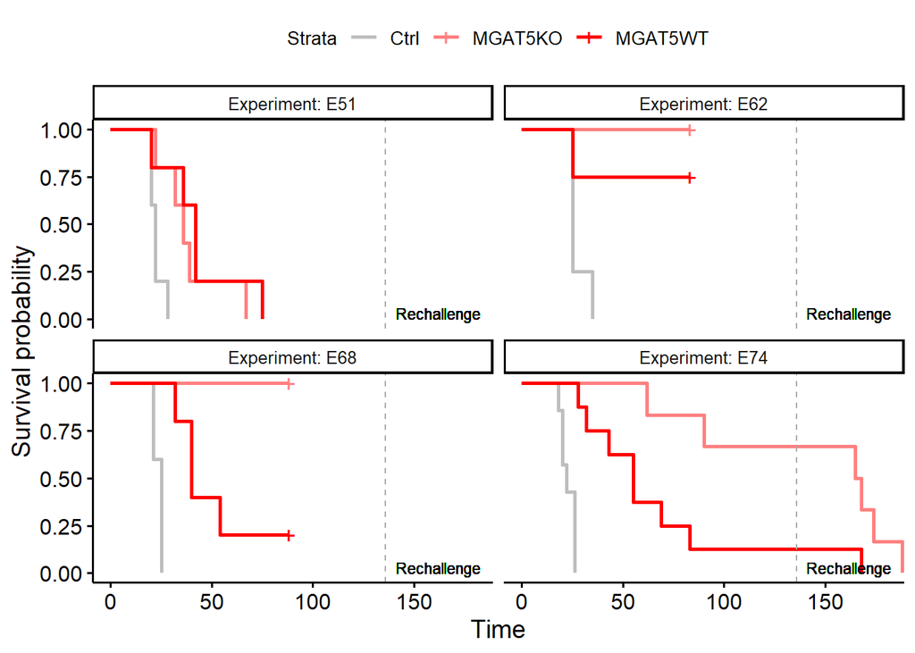

```r
CD70_perexp
```

```r
survdiff(Surv(Time_FU_1, Event1) ~ MGAT5, data = CD70 %>% filter(MGAT5 != 'Ctrl'))
```

```
## Call:
## survdiff(formula = Surv(Time_FU_1, Event1) ~ MGAT5, data = CD70 %>%
##     filter(MGAT5 != "Ctrl"))
##
##                N Observed Expected (O-E)^2/E (O-E)^2/V
## MGAT5=MGAT5WT 22       17     10.8      3.62      6.92
## MGAT5=MGAT5KO 19        7     13.2      2.94      6.92
##
##  Chisq= 6.9  on 1 degrees of freedom, p= 0.009
```

```r
survdiff(Surv(Time_FU_2, Event2) ~ MGAT5, data = CD70 %>% filter(MGAT5 != 'Ctrl'))
```

```
## Call:
## survdiff(formula = Surv(Time_FU_2, Event2) ~ MGAT5, data = CD70 %>%
##     filter(MGAT5 != "Ctrl"))
##
## n=5, 36 observations deleted due to missingness.
##
##               N Observed Expected (O-E)^2/E (O-E)^2/V
## MGAT5=MGAT5WT 1        1      0.7    0.1286      0.22
## MGAT5=MGAT5KO 4        4      4.3    0.0209      0.22
##
##  Chisq= 0.2  on 1 degrees of freedom, p= 0.6
```

# Survival analysis only primary and per donor

We will do the survival analysis per target. A certain dose was used as the ‘standard’ dose, and this is repeated in each experiment: - control (NTC): 4 million cells, all experiments - CD70: 4 million cells, all exps

We collect the data for each analysis in a separate dataframe. We also remove all mice that died from other causes (e.g. GVHD)

```r
Survival <- Survival %>%
  mutate(Event = Event1,
         Time_FU = Time_FU_1,
         cMGAT5 = as.character(MGAT5))

CD70 <- Survival %>%
  filter((Target == 'CD70' & Dose == '4') |
           (Target == 'Ctrl' & Dose == '4')) %>%
  filter(Event %in% c('0', '1'))

surv_CD70 <- Surv(CD70$Time_FU, CD70$Event)

simple_palette_CD70= c('grey',
                       rgb(255,0,0, maxColorValue = 255),
                       rgb(255,128,128, maxColorValue = 255))
stratify_palette_CD70 = c('grey',
                          rgb(255,128,128, maxColorValue = 255),
                          rgb(255,0,0, maxColorValue = 255))
```

## CD70

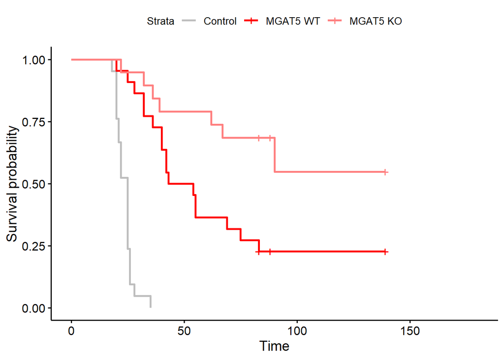

```r
sCD70 <- survfit2(surv_CD70 ~ MGAT5, data = CD70)
CD70_combi <- ggsurvplot(sCD70, data = CD70, palette = simple_palette_CD70,
                         legend.labs = c('Control', 'MGAT5 WT', 'MGAT5 KO'),
                         xlim = c(0,180))
CD70_perexp <- ggsurvplot_facet(sCD70, facet.by = 'Experiment', data = CD70,
                                palette = stratify_palette_CD70,
                                xlim = c(0,180))

CD70_combi$plot <- CD70_combi$plot

CD70_perexp <- CD70_perexp

ggsave(here('output/CD70_combi_primaryOnly.pdf'), CD70_combi$plot,
       device = 'pdf', width  = 8, height = 5)

ggsave(here('output/CD70_perexp_primaryOnly.pdf'), CD70_perexp,
       device = 'pdf', width = 8, height = 5)

CD70_combi
```

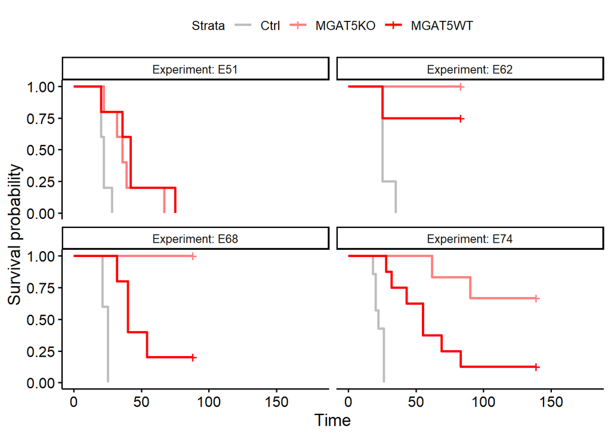

```r
CD70_perexp
```

```r
CD70 %>%
  filter(MGAT5 != 'Ctrl') %>%
  group_by(Experiment) %>%
  summarise(pval = survdiff(Surv(Time_FU_1, Event1) ~ MGAT5)$pval %>% round(.,3)) %>%
  mutate(Model = 'Raji, anti-CD70, Survival for primary tumor') %>%
  select(Model, everything())
```

```
## # A tibble: 4 × 3
##   Model                                       Experiment  pval
##   <chr>                                       <fct>      <dbl>
## 1 Raji, anti-CD70, Survival for primary tumor E51        0.388
## 2 Raji, anti-CD70, Survival for primary tumor E62        0.317
## 3 Raji, anti-CD70, Survival for primary tumor E68        0.026
## 4 Raji, anti-CD70, Survival for primary tumor E74        0.019
```

```r
citation()
```

```
##
##   R Core Team (2024). _R: A Language and Environment for Statistical
##   Computing_. R Foundation for Statistical Computing, Vienna, Austria.
##   <https://www.R-project.org/>.
##
## A BibTeX entry for LaTeX users is
##
##   @Manual{,
##     title = {R: A Language and Environment for Statistical Computing},
##     author = {{R Core Team}},
##     organization = {R Foundation for Statistical Computing},
##     address = {Vienna, Austria},
##     year = {2024},
##     url = {https://www.R-project.org/},
##   }
##
## We have invested a lot of time and effort in creating R, please cite it
## when using it for data analysis. See also 'citation("pkgname")' for
## citing R packages.
```